# Analyzing Shooting Incidents in New York City

Adib Sobhanian

2024-02-23

# Introduction

The **NYPD Shooting Incident Data (Historic)** provides a comprehensive record of shooting incidents that have occurred in New York City since 2006 up to the end of the previous calendar year. This dataset is periodically updated and maintained by the New York City Police Department (NYPD), with the metadata last updated on September 2, 2023.

## Background

The NYPD Shooting Incident Data (Historic) dataset serves as a detailed record of each shooting incident, providing valuable insights into the nature and characteristics of gun-related crimes within the city. Compiled and maintained by the Office of Management Analysis and Planning, the dataset undergoes manual extraction every quarter and rigorous review processes before being made available to the public via the NYPD website.

## Purpose

The analysis of this dataset aims to explore the nature of shooting incidents in New York City, identify temporal and spatial patterns, and investigate demographic factors associated with these incidents. By analyzing this data, we seek to gain insights that can inform strategies for crime prevention and law enforcement efforts. Please refer to the attached data footnotes for additional information about this dataset.

## Libraries used for this analysis

```r
library(tidyverse)
```

```r
library(lubridate)
library(ggplot2)
library(dplyr)
library(broom)
library(caret)
```

## Data Sources

This data is manually extracted every quarter by the Office of Management Analysis and Planning within the NYPD. It undergoes a review process before being made publicly available on the NYPD website. The dataset is provided in CSV format and can be accessed from [data.gov](https://catalog.data.gov/dataset/nypd-shooting-incident-data-historic).

## Data Loading

```r
NYPD_shooting_data <- read.csv("https://data.cityofnewyork.us/api/views/833y-fsy8/rows.csv?accessType=DOWNLOAD")
```

## Data Cleaning

Chechking the summary of data imported

```r
summary(NYPD_shooting_data)
```

```
##   INCIDENT_KEY        OCCUR_DATE         OCCUR_TIME            BORO
##  Min.   :  9953245   Length:27312       Length:27312       Length:27312
##  1st Qu.: 63860880   Class :character   Class :character   Class :character
##  Median : 90372218   Mode  :character   Mode  :character   Mode  :character
##  Mean   :120860536
##  3rd Qu.:188810230
##  Max.   :261190187
##
##  LOC_OF_OCCUR_DESC     PRECINCT      JURISDICTION_CODE LOC_CLASSFCTN_DESC
##  Length:27312       Min.   :  1.00   Min.   :0.0000    Length:27312
##  Class :character   1st Qu.: 44.00   1st Qu.:0.0000    Class :character
##  Mode  :character   Median : 68.00   Median :0.0000    Mode  :character
##                     Mean   : 65.64   Mean   :0.3269
##                     3rd Qu.: 81.00   3rd Qu.:0.0000
##                     Max.   :123.00   Max.   :2.0000
##                                      NA's   :2
##  LOCATION_DESC      STATISTICAL_MURDER_FLAG PERP_AGE_GROUP
##  Length:27312       Length:27312            Length:27312
##  Class :character   Class :character        Class :character
##  Mode  :character   Mode  :character        Mode  :character
##
##
##
##
##    PERP_SEX          PERP_RACE         VIC_AGE_GROUP        VIC_SEX
##  Length:27312       Length:27312       Length:27312       Length:27312
##  Class :character   Class :character   Class :character   Class :character
##  Mode  :character   Mode  :character   Mode  :character   Mode  :character
##
##
##
##
##    VIC_RACE           X_COORD_CD        Y_COORD_CD        Latitude
##  Length:27312       Min.   : 914928   Min.   :125757   Min.   :40.51
##  Class :character   1st Qu.:1000029   1st Qu.:182834   1st Qu.:40.67
##  Mode  :character   Median :1007731   Median :194487   Median :40.70
##                     Mean   :1009449   Mean   :208127   Mean   :40.74
##                     3rd Qu.:1016838   3rd Qu.:239518   3rd Qu.:40.82
##                     Max.   :1066815   Max.   :271128   Max.   :40.91
##                                                        NA's   :10
##    Longitude        Lon_Lat
##  Min.   :-74.25   Length:27312
##  1st Qu.:-73.94   Class :character
##  Median :-73.92   Mode  :character
##  Mean   :-73.91
##  3rd Qu.:-73.88
##  Max.   :-73.70
##  NA's   :10
```

Based on the summary of the data, it seems that the following columns may not be needed for our analysis so we can remove them, and converting the date and time to time objects.

```r
NYPD_shooting_clean <- NYPD_shooting_data %>%
  select(-c(X_COORD_CD, Y_COORD_CD, Latitude, Longitude, INCIDENT_KEY,Lon_Lat,LOC_CLASSFCTN_DESC,LOCATION_DESC)) %>%
  mutate(OCCUR_DATE = mdy(OCCUR_DATE),
         OCCUR_TIME = hms(OCCUR_TIME))
```

We can check the summary and the first few line of the data

```r
head(NYPD_shooting_clean)
```

```
##   OCCUR_DATE OCCUR_TIME     BORO LOC_OF_OCCUR_DESC PRECINCT JURISDICTION_CODE
## 1 2021-05-27 21H 30M 0S   QUEENS                        105                 0
## 2 2014-06-27 17H 40M 0S    BRONX                         40                 0
## 3 2015-11-21  3H 56M 0S   QUEENS                        108                 0
## 4 2015-10-09 18H 30M 0S    BRONX                         44                 0
## 5 2009-02-19 22H 58M 0S    BRONX                         47                 0
## 6 2020-10-21 21H 36M 0S BROOKLYN                         81                 0
##   STATISTICAL_MURDER_FLAG PERP_AGE_GROUP PERP_SEX PERP_RACE VIC_AGE_GROUP
## 1                   false                                           18-24
## 2                   false                                           18-24
## 3                    true                                           25-44
## 4                   false                                             <18
## 5                    true          25-44        M     BLACK         45-64
## 6                    true                                           25-44
##   VIC_SEX       VIC_RACE
## 1       M          BLACK
## 2       M          BLACK
## 3       M          WHITE
## 4       M WHITE HISPANIC
## 5       M          BLACK
## 6       M          BLACK
```

Seems like there are some missing data in our data and we need to think of how we want to handle the missing data from the beginning. First let’s check to see how many missing rows are in each column using sapply() function

```r
sapply(NYPD_shooting_clean, function(x) sum(x == ""))
```

```
##              OCCUR_DATE              OCCUR_TIME                    BORO
##                      NA                      NA                       0
##       LOC_OF_OCCUR_DESC                PRECINCT       JURISDICTION_CODE
##                   25596                       0                      NA
## STATISTICAL_MURDER_FLAG          PERP_AGE_GROUP                PERP_SEX
##                       0                    9344                    9310
##               PERP_RACE           VIC_AGE_GROUP                 VIC_SEX
##                    9310                       0                       0
##                VIC_RACE
##                       0
```

It seems like there are some missing values in some columns particularly the data regarding the predator information, this is probably due to missing suspect or open cases that don’t have proper data on them. We can ignore them in the time being.

```r
# Check for complete cases (rows with no missing values)
complete_rows <- complete.cases(NYPD_shooting_clean)

# Count the number of complete and incomplete rows
num_complete <- sum(complete_rows)
num_incomplete <- sum(!complete_rows)

cat("Number of complete rows:", num_complete, "\n")
```

```
## Number of complete rows: 27310
```

```r
cat("Number of incomplete rows:", num_incomplete, "\n")
```

```
## Number of incomplete rows: 2
```

Now we can remove the rows with completely empty cells

```r
# Remove rows with missing values
NYPD_shooting_clean <- NYPD_shooting_clean[complete_rows, ]
```

Now lets check the format of all column to make sure they are entered correctly and their data makes sense.

```r
table(NYPD_shooting_clean$PERP_AGE_GROUP)
```

```
##
##          (null)     <18    1020   18-24     224   25-44   45-64     65+     940
##    9344     640    1590       1    6222       1    5687     617      60       1
## UNKNOWN
##    3147
```

```r
table(NYPD_shooting_clean$VIC_AGE_GROUP)
```

```
##
##     <18    1022   18-24   25-44   45-64     65+ UNKNOWN
##    2839       1   10085   12280    1863     181      61
```

```r
table(NYPD_shooting_clean$BORO)
```

```
##
##         BRONX      BROOKLYN     MANHATTAN        QUEENS STATEN ISLAND
##          7937         10933          3571          4093           776
```

```r
table(NYPD_shooting_clean$STATISTICAL_MURDER_FLAG)
```

```
##
## false  true
## 22044  5266
```

It appears that we have a value that does not match the expected format in PERP_AGE_GROUP, and VIC_AGE_GROUP. We can filter them out.

```r
NYPD_clean_filtered <- NYPD_shooting_clean %>%
  filter(VIC_AGE_GROUP != "1022") %>%
  filter(!(PERP_AGE_GROUP %in% c("1020", "940", "224")))
```

Let also change the STATISTICAL_MURDER_FLAG column to FATAL and Non_Fatal format for easier understanding of the audience.

```r
STATISTICAL_MURDER_FLAG_factor <- as.factor(NYPD_clean_filtered$STATISTICAL_MURDER_FLAG)

NYPD_clean_filtered <- NYPD_clean_filtered %>%
  mutate(Outcome = ifelse(STATISTICAL_MURDER_FLAG, "Fatal", "Non_Fatal"))
```

Lastly, lets parse the OCCUR_DATE into Year, Month, and Weekday.

```r
NYPD_clean_filtered <- NYPD_clean_filtered %>%
  mutate(OCCUR_DATE = parse_date_time(as.character(OCCUR_DATE), orders = c("mdy", "my", "ymd")),
         Year = year(OCCUR_DATE),
         Month = month(OCCUR_DATE, label = TRUE),
         Weekday = format(OCCUR_DATE, "%A"))
```

## Exploratory Data Analysis and Visualizations

To get a basic idea for our analysis lets create some basic summary statistics, plots, and visualizations to help us explore our data visually and statistically to gain insights into its distribution, relationships, and patterns.

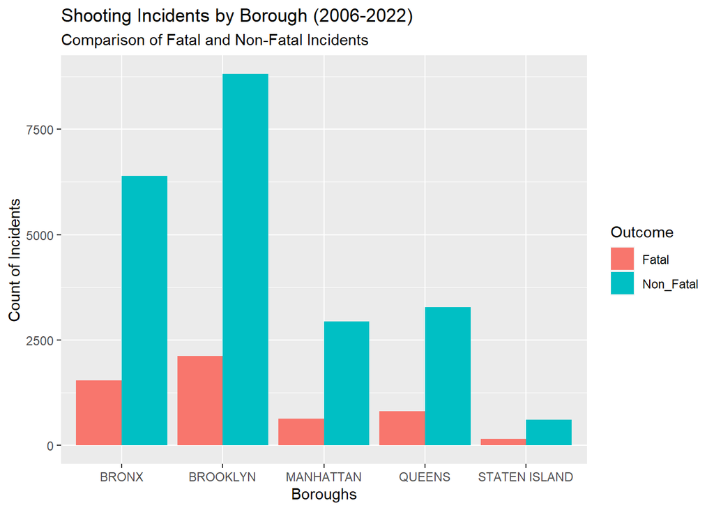

```r
ggplot(NYPD_clean_filtered, aes(x = BORO,fill = Outcome)) +
geom_bar(position = "dodge") +
labs(x = "Boroughs", y = "Count of Incidents", title = "Shooting Incidents by Borough (2006-2022)", subtitle = "Comparison of Fatal and Non-Fatal Incidents")
```

```r
theme(plot.title = element_text(hjust = 0.5), plot.subtitle = element_text(hjust = 0.5))
```

[output not shown]

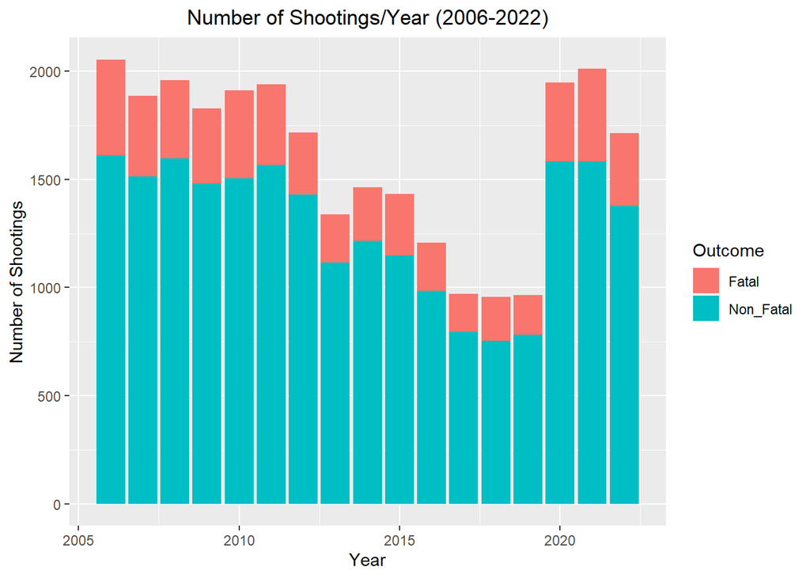

```r
ggplot(NYPD_clean_filtered, aes(x = Year,fill = Outcome)) +
geom_bar() +
labs(title = "Number of Shootings/Year (2006-2022)",
x = "Year",
y = "Number of Shootings")+
theme(plot.title = element_text(hjust = 0.5), plot.subtitle = element_text(hjust = 0.5))
```

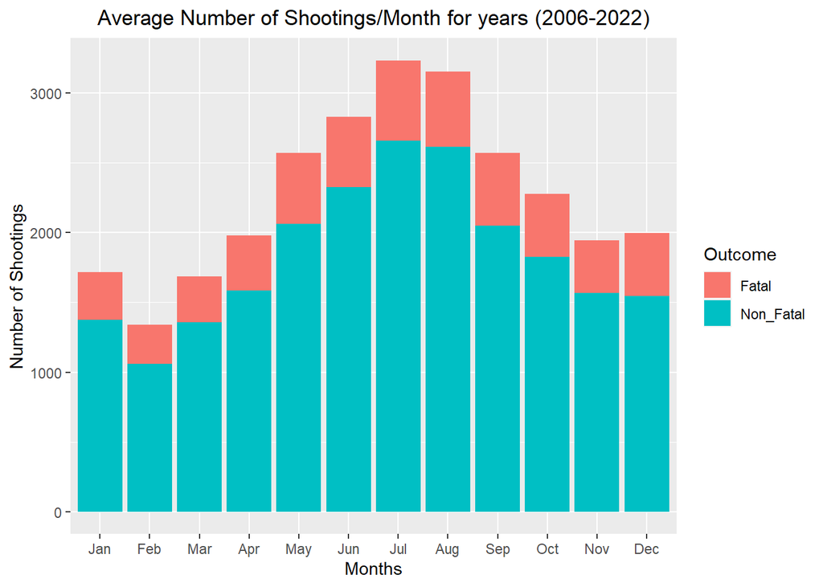

```r
ggplot(NYPD_clean_filtered, aes(x = Month, fill = Outcome)) +
geom_bar() +
labs(title = "Average Number of Shootings/Month for years (2006-2022)",
x = "Months",
y = "Number of Shootings")+
theme(plot.title = element_text(hjust = 0.5), plot.subtitle = element_text(hjust = 0.5))
```

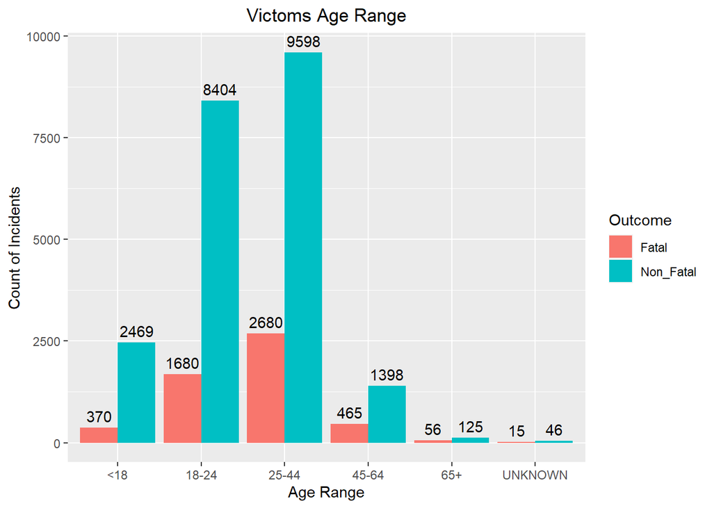

```r
ggplot(NYPD_clean_filtered, aes(x = VIC_AGE_GROUP, fill = Outcome)) +
geom_bar(position = "dodge") +
geom_text(stat = 'count', aes(label = after_stat(count)), position = position_dodge(width = 0.9), vjust = -0.5) +
labs(title = "Victoms Age Range",
x = "Age Range",
y = "Count of Incidents",
fill = "Outcome") +theme(plot.title = element_text(hjust = 0.5))
```

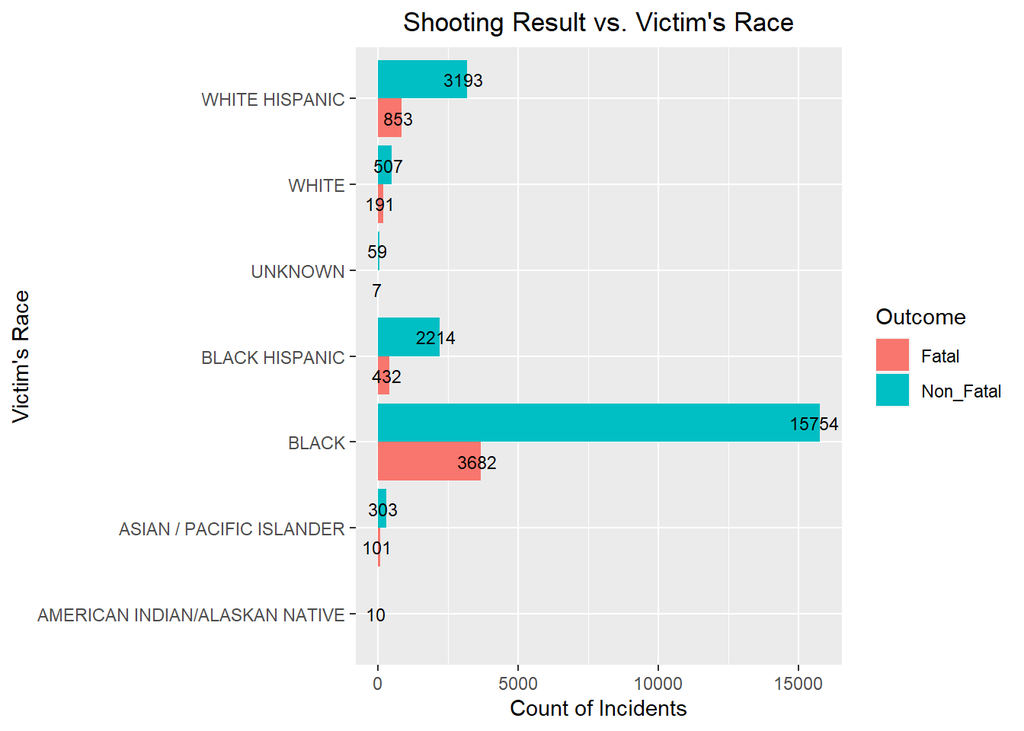

```r
ggplot(NYPD_clean_filtered, aes(x = VIC_RACE, fill = Outcome)) +
geom_bar(position = "dodge") +
geom_text(stat = 'count', aes(label = after_stat(count), group = Outcome),
position = position_dodge(width = 0.9), hjust = .6, size = 3)+
coord_flip()+
labs(title = "Shooting Result vs. Victim's Race",
x = "Victim's Race",
y = "Count of Incidents",
fill = "Outcome") + theme(plot.title = element_text(hjust = 0.5))
```

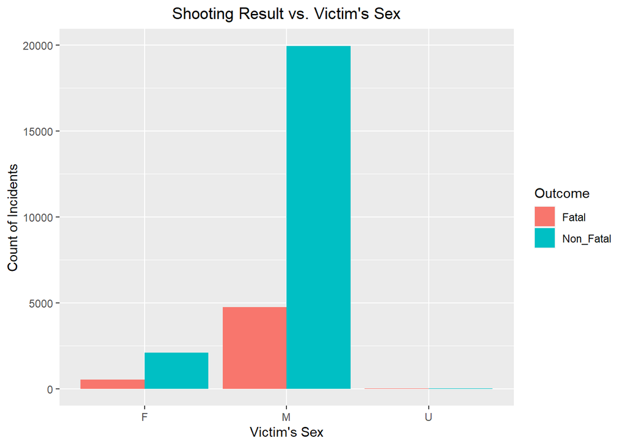

```r
ggplot(NYPD_clean_filtered, aes(x = VIC_SEX, fill = Outcome)) +
geom_bar(position = "dodge")+
labs(title = "Shooting Result vs. Victim's Sex",
x = "Victim's Sex",
y = "Count of Incidents",
fill = "Outcome") + theme(plot.title = element_text(hjust = 0.5))
```

## Model

```r
NYPD_clean_filtered$Outcome <- ifelse(NYPD_clean_filtered$Outcome == "Fatal", 1, 0)
```

Data Splitting: Splits the dataset (NYPD_clean_filtered) into training and testing sets. It uses the createDataPartition function from the caret package to randomly partition the data into 80% training and 20% testing sets, ensuring reproducibility by setting the seed with set.seed(123).

Model Training: Fits a logistic regression model (glm) to the training data. The formula Outcome ~ . specifies that the target variable “Outcome” is regressed against all other variables in the dataset. The family = binomial argument indicates that logistic regression should be used, and maxit = 1000 increases the maximum number of iterations to 1000 to prevent convergence issues.

Tidying Model Results: The tidy function from the broom package is applied to the model object to extract tidy results, such as coefficients and standard errors, into a data frame (tidy_results).

Making Predictions: The trained model is used to make predictions on the test data using the predict function. Setting type = “response” ensures that predicted probabilities are returned. Predicted probabilities are then converted to factor levels (0 or 1) based on a threshold of 0.5 using ifelse, and the factor levels of the actual test data are adjusted accordingly.

This code prepares and fits a logistic regression model, makes predictions on the test data, and ensures that the predictions and actual outcomes are in the correct format for evaluation.

```r
features <- c("BORO", "OCCUR_DATE", "OCCUR_TIME", "VIC_AGE_GROUP", "VIC_SEX", "VIC_RACE")
target <- "Outcome"

# Split data into training and testing sets
set.seed(123)  # For reproducibility
train_indices <- createDataPartition(NYPD_clean_filtered$Outcome, p = 0.8, list = FALSE)
train_data <- NYPD_clean_filtered[train_indices, ]
test_data <- NYPD_clean_filtered[-train_indices, ]

# Train logistic regression model
model <- glm(Outcome ~ ., data = train_data, family = binomial, maxit = 1000)
# Tidy the model results
tidy_results <- tidy(model)

# Make predictions on test data
predictions <- predict(model, newdata = test_data, type = "response")

predictions <- factor(ifelse(predictions >= 0.5, 1, 0), levels = c(0, 1))
test_data$Outcome <- factor(test_data$Outcome, levels = c(0, 1))
```

## Evaluate

To evaluate the performance of your logistic regression model, you can use various metrics depending on the nature of your problem (e.g., binary classification). Here are some commonly used metrics and how to compute them in R:

Accuracy: The proportion of correct predictions out of the total predictions.

```r
accuracy <- mean(predictions == test_data$Outcome)
accuracy
```

```
## [1] 1
```

Confusion Matrix: A table showing the counts of true positive, true negative, false positive, and false negative predictions.

```r
conf_matrix <- confusionMatrix(predictions, test_data$Outcome)
conf_matrix
```

```
## Confusion Matrix and Statistics
##
##           Reference
## Prediction    0    1
##          0 4439    0
##          1    0 1022
##
##                Accuracy : 1
##                  95% CI : (0.9993, 1)
##     No Information Rate : 0.8129
##     P-Value [Acc > NIR] : < 2.2e-16
##
##                   Kappa : 1
##
##  Mcnemar's Test P-Value : NA
##
##             Sensitivity : 1.0000
##             Specificity : 1.0000
##          Pos Pred Value : 1.0000
##          Neg Pred Value : 1.0000
##              Prevalence : 0.8129
##          Detection Rate : 0.8129
##    Detection Prevalence : 0.8129
##       Balanced Accuracy : 1.0000
##
##        'Positive' Class : 0
##
```

Precision: The proportion of true positive predictions out of the total positive predictions.

```r
precision <- conf_matrix$byClass["Pos Pred Value"]
```

Recall (Sensitivity): The proportion of true positive predictions out of the actual positives.

```r
recall <- conf_matrix$byClass["Sensitivity"]
```

F1 Score: The harmonic mean of precision and recall, providing a balance between the two.

```r
f1_score <- 2 * (precision * recall) / (precision + recall)
```

## Result

Confusion Matrix: The confusion matrix shows that the model made correct predictions for all instances of both classes. There are no false positives or false negatives, indicating perfect classification performance.

Accuracy: The accuracy of the model is 1, which means that it correctly classified all instances in the test dataset.

F1 Score: The F1 score is also 1, which is the harmonic mean of precision and recall. This further confirms the excellent performance of the model.

Overall, the model appears to be performing exceptionally well on the test dataset. However, it’s important to consider the context of your problem and the dataset characteristics. Perfect performance could indicate potential issues such as overfitting, especially if the dataset is small or highly imbalanced.

Additionally, it’s essential to evaluate the model on unseen data or through cross-validation to ensure its generalizability. If the performance holds up on independent datasets, you can have confidence in the model’s effectiveness for your predictive task.

```r
conf_matrix
```

```
## Confusion Matrix and Statistics
##
##           Reference
## Prediction    0    1
##          0 4439    0
##          1    0 1022
##
##                Accuracy : 1
##                  95% CI : (0.9993, 1)
##     No Information Rate : 0.8129
##     P-Value [Acc > NIR] : < 2.2e-16
##
##                   Kappa : 1
##
##  Mcnemar's Test P-Value : NA
##
##             Sensitivity : 1.0000
##             Specificity : 1.0000
##          Pos Pred Value : 1.0000
##          Neg Pred Value : 1.0000
##              Prevalence : 0.8129
##          Detection Rate : 0.8129
##    Detection Prevalence : 0.8129
##       Balanced Accuracy : 1.0000
##
##        'Positive' Class : 0
##
```

```r
precision
```

```
## Pos Pred Value
##              1
```

```r
recall
```

```
## Sensitivity
##           1
```

```r
f1_score
```

```
## Pos Pred Value
##              1
```

## Analysis of Logistic Regression Results

Implications: Understanding the factors associated with fatal shooting incidents can provide valuable insights for policymakers, law enforcement agencies, and community organizations. By identifying high-risk areas and vulnerable populations, interventions and resources can be targeted more effectively to prevent and mitigate the impact of such incidents.

## Biases

It’s important to acknowledge potential biases that may influence the analysis of the NYPD shooting incident data. These biases include underreporting, selection bias, demographic bias, spatial bias, temporal bias, data cleaning bias, and modeling bias. For instance, underreporting bias may lead to an incomplete picture of shooting incidents, while demographic biases in the dataset could skew the analysis of victim and perpetrator characteristics. Spatial and temporal biases could affect the interpretation of geographic and temporal patterns in the data. Additionally, decisions made during data cleaning and modeling processes may introduce biases into the analysis. Recognizing and addressing these biases is essential to ensure that the findings accurately reflect the reality of shooting incidents in New York City.